# Intro to R

Day 13: Working with binary data

Class date: 04/18/2017 Last update: 04/20/17

First we will look at a simple case of binary data. We use the `mtcars` dataset. Let’s get some descriptives.

```r
str(mtcars)
```

```
## 'data.frame':    32 obs. of  11 variables:
##  $ mpg : num  21 21 22.8 21.4 18.7 18.1 14.3 24.4 22.8 19.2 ...
##  $ cyl : num  6 6 4 6 8 6 8 4 4 6 ...
##  $ disp: num  160 160 108 258 360 ...
##  $ hp  : num  110 110 93 110 175 105 245 62 95 123 ...
##  $ drat: num  3.9 3.9 3.85 3.08 3.15 2.76 3.21 3.69 3.92 3.92 ...
##  $ wt  : num  2.62 2.88 2.32 3.21 3.44 ...
##  $ qsec: num  16.5 17 18.6 19.4 17 ...
##  $ vs  : num  0 0 1 1 0 1 0 1 1 1 ...
##  $ am  : num  1 1 1 0 0 0 0 0 0 0 ...
##  $ gear: num  4 4 4 3 3 3 3 4 4 4 ...
##  $ carb: num  4 4 1 1 2 1 4 2 2 4 ...
```

```r
# make subset of mtcars
# keep column 'mpg' and 'am'

my_cars <- mtcars[, c('mpg', 'am')]

# calculate mean 'mpg' as a function of 'am'
(my_agg <- aggregate(mpg ~ am, FUN = mean, data = my_cars))
```

```
##   am      mpg
## 1  0 17.14737
## 2  1 24.39231
```

Now let’s make a plot. We’ll start simple and make a bar graph using the means we calculated above.

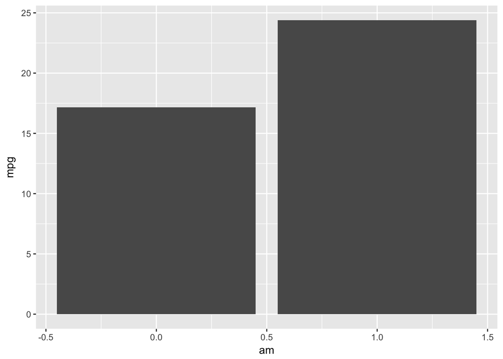

```r
# make a plot
library(tidyverse)
ggplot(my_agg, aes(x = am, y = mpg)) +
 geom_col()
```

Rather ugly, but it works. We can use ggplot to calculate descriptives for us. We will use `stat_summary` to calculate the mean and the standar error. This is much more informative than a bar graph and avoids including 0.

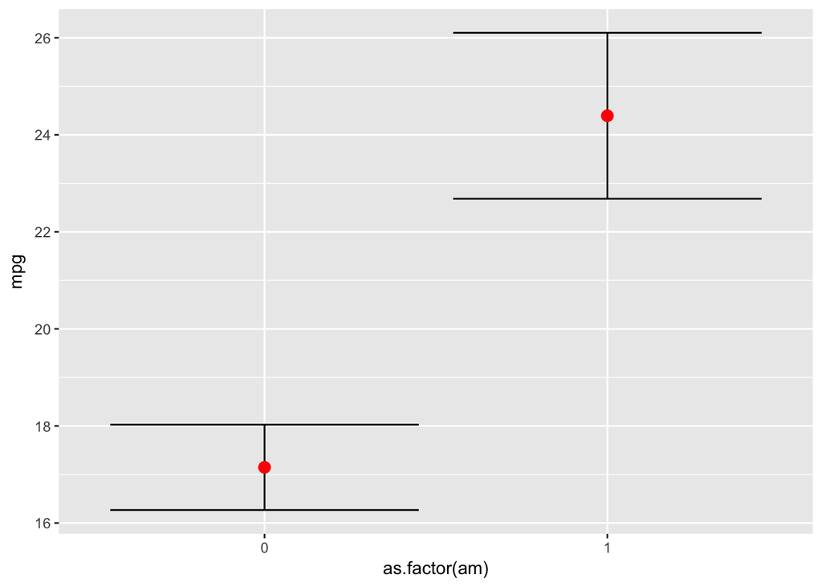

```r
ggplot(my_cars, aes(x = as.factor(am), y = mpg)) +
  stat_summary(fun.data = 'mean_se', geom = 'errorbar') +
  stat_summary(fun.y = 'mean', geom = 'point', color = 'red', size = 3)
```

Ok. Now let’s flip our DV and IV. We will look at `am` as a function of `mpg` (automatic/manual transmition as a function of gas milleage).

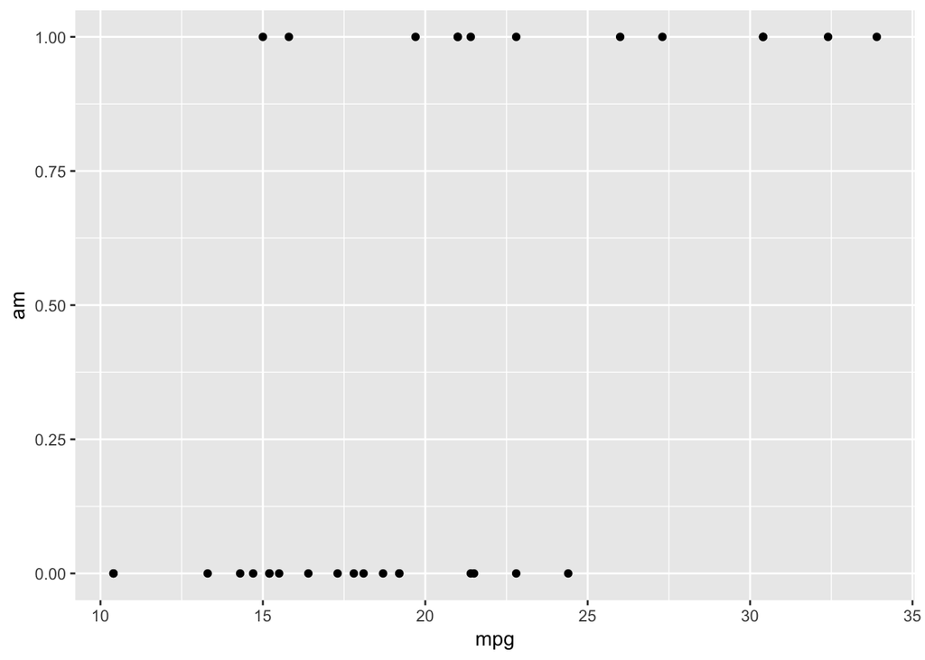

```r
ggplot(my_cars, aes(x = mpg, y = am)) +
  geom_point()
```

Looks good. We can fit a model to the data using `geom_smooth`.

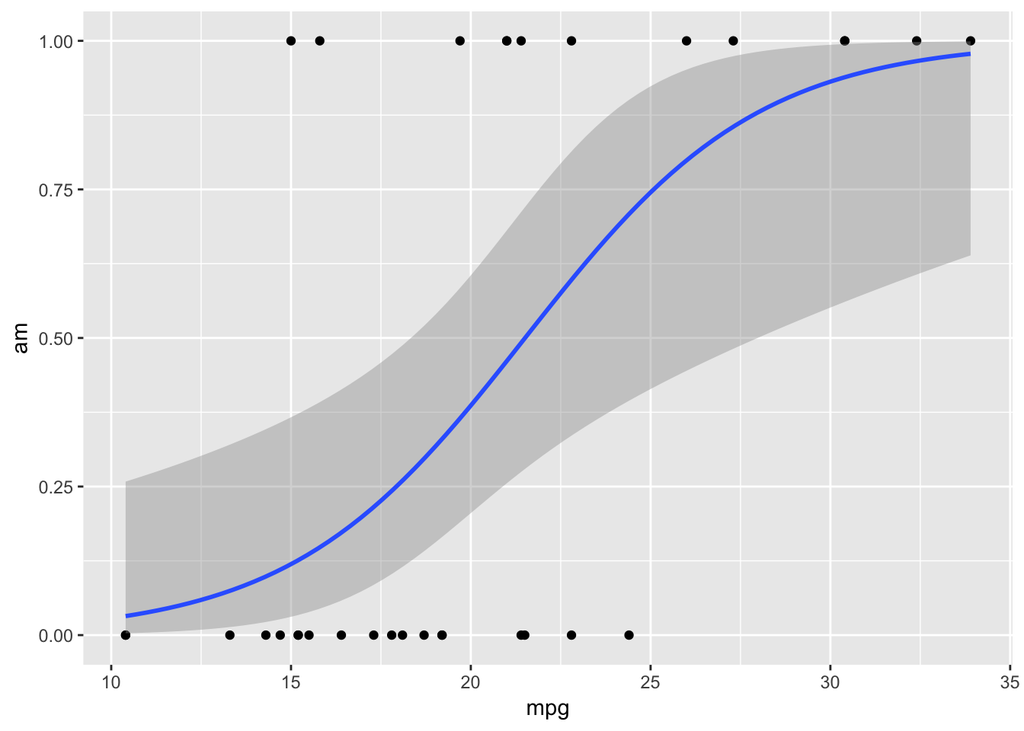

```r
ggplot(my_cars, aes(x = mpg, y = am)) +
  geom_point() +
  geom_smooth(method = 'glm', method.args = list(family = "binomial"))
```

Good. Now let’s generate some data to plot something more interesting.

```r
# Generate data
var1  <- c(0, 0, 0, 0, 1, 1, 1)
var2  <- c(0, 0, 0, 1, 1, 1, 1)
var3  <- c(0, 0, 1, 0, 1, 1, 1)
var4  <- c(0, 0, 0, 1, 0, 1, 1)
var5  <- c(1, 0, 1, 0, 1, 1, 1)
var6  <- c(0, 0, 0, 1, 1, 1, 1)
var7  <- c(0, 0, 0, 0, 1, 1, 0)
var8  <- c(0, 0, 0, 0, 0, 1, 1)
var9  <- c(0, 1, 0, 1, 1, 0, 1)
var10 <- c(0, 0, 0, 1, 1, 1, 1)
resp <- rep(c(var1, var2, var3, var4, var5, var6, var7, var8, var9, var10), times = 10)

partN  <- 1:100
subjId <- rep(paste0('subj', partN), each = 7)
my_df  <- data.frame(subjId,
                     stim = rep(1:7, times = 100),
                     response = resp)

str(my_df)
```

```
## 'data.frame':    700 obs. of  3 variables:
##  $ subjId  : Factor w/ 100 levels "subj1","subj10",..: 1 1 1 1 1 1 1 13 13 13 ...
##  $ stim    : int  1 2 3 4 5 6 7 1 2 3 ...
##  $ response: num  0 0 0 0 1 1 1 0 0 0 ...
```

```r
head(my_df)
```

```
##   subjId stim response
## 1  subj1    1        0
## 2  subj1    2        0
## 3  subj1    3        0
## 4  subj1    4        0
## 5  subj1    5        1
## 6  subj1    6        1
```

```r
tail(my_df)
```

```
##      subjId stim response
## 695 subj100    2        0
## 696 subj100    3        0
## 697 subj100    4        1
## 698 subj100    5        1
## 699 subj100    6        1
## 700 subj100    7        1
```

Again we can calculate descriptives and plot them.

```r
(my_avg <- aggregate(response ~ as.factor(stim), FUN = mean, data = my_df))
```

```
##   as.factor(stim) response
## 1               1      0.1
## 2               2      0.1
## 3               3      0.2
## 4               4      0.5
## 5               5      0.8
## 6               6      0.9
## 7               7      0.9
```

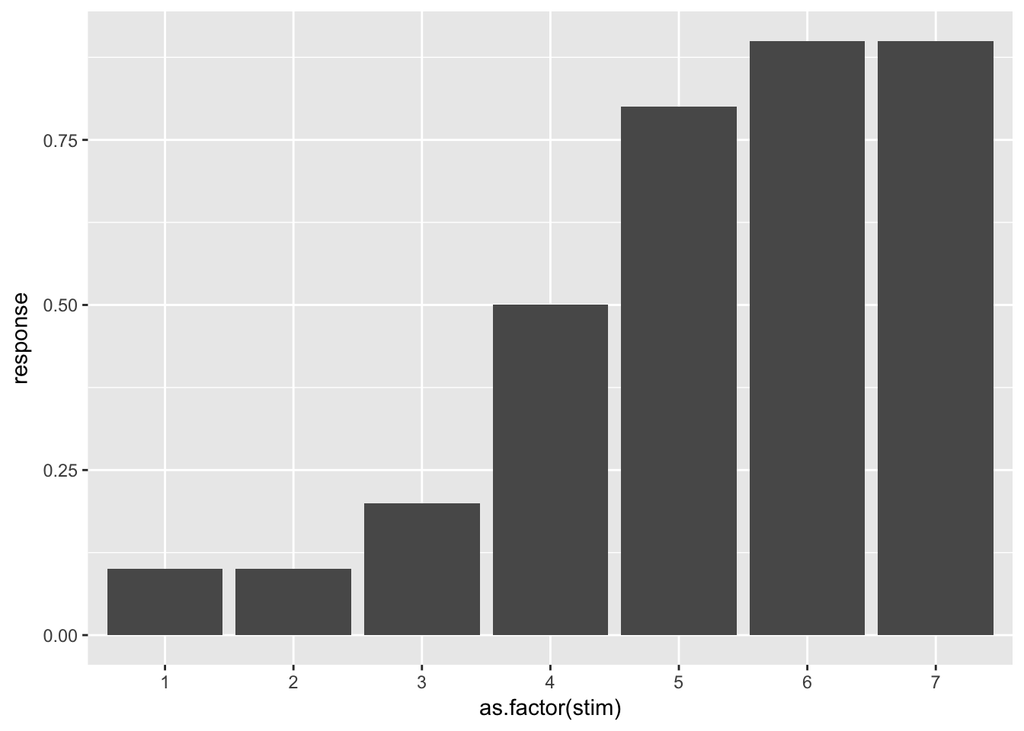

```r
ggplot(my_avg, aes(x = `as.factor(stim)`, y = response)) +
  geom_col()
```

This works but let’s try using what we learned above. We can also make the points more interpretable using `geom_jitter`.

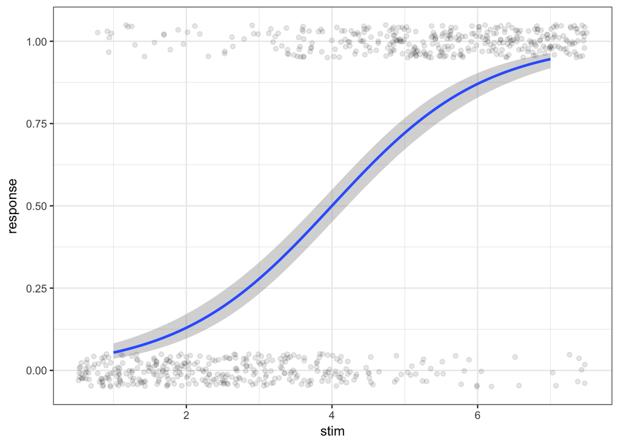

```r
ggplot(my_df, aes(x = stim, y = response)) +
  geom_jitter(width = 0.5, height = 0.05, alpha = 0.1) +
  geom_smooth(method = 'glm', method.args = list(family = 'binomial')) +
  theme_bw()
```

Another option (probably a better one) is to fit an actual model and plot that.

```r
my_glm <- glm(response ~ stim, data = my_df, family = 'binomial')
summary(my_glm)
```

```
##
## Call:
## glm(formula = response ~ stim, family = "binomial", data = my_df)
##
## Deviance Residuals:
##     Min       1Q   Median       3Q      Max
## -2.4142  -0.5266   0.0000   0.5266   2.4142
##
## Coefficients:
##             Estimate Std. Error z value Pr(>|z|)
## (Intercept) -3.81127    0.28646  -13.30   <2e-16 ***
## stim         0.95282    0.06701   14.22   <2e-16 ***
## ---
## Signif. codes:  0 '***' 0.001 '**' 0.01 '*' 0.05 '.' 0.1 ' ' 1
##
## (Dispersion parameter for binomial family taken to be 1)
##
##     Null deviance: 970.41  on 699  degrees of freedom
## Residual deviance: 613.66  on 698  degrees of freedom
## AIC: 617.66
##
## Number of Fisher Scoring iterations: 5
```

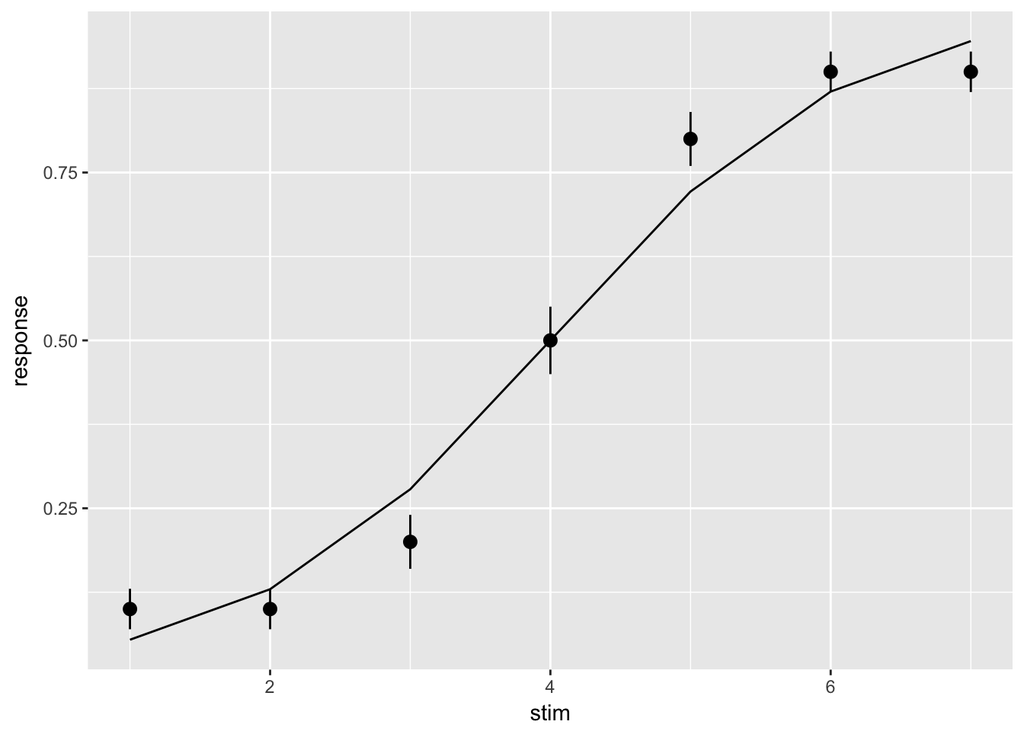

```r
ggplot(my_df, aes(x = stim, y = response)) +
  stat_summary(fun.data = 'mean_se', geom = 'pointrange') +
  stat_summary(aes(y = fitted(my_glm)), fun.y = 'mean', geom = 'line')
```

What about completely categorical data? Let’s go back to the `mtcars` dataset.

```r
str(mtcars)
```

```
## 'data.frame':    32 obs. of  11 variables:
##  $ mpg : num  21 21 22.8 21.4 18.7 18.1 14.3 24.4 22.8 19.2 ...
##  $ cyl : num  6 6 4 6 8 6 8 4 4 6 ...
##  $ disp: num  160 160 108 258 360 ...
##  $ hp  : num  110 110 93 110 175 105 245 62 95 123 ...
##  $ drat: num  3.9 3.9 3.85 3.08 3.15 2.76 3.21 3.69 3.92 3.92 ...
##  $ wt  : num  2.62 2.88 2.32 3.21 3.44 ...
##  $ qsec: num  16.5 17 18.6 19.4 17 ...
##  $ vs  : num  0 0 1 1 0 1 0 1 1 1 ...
##  $ am  : num  1 1 1 0 0 0 0 0 0 0 ...
##  $ gear: num  4 4 4 3 3 3 3 4 4 4 ...
##  $ carb: num  4 4 1 1 2 1 4 2 2 4 ...
```

```r
# make subset of categorical data
vs_am <- mtcars %>%
  select(vs, am)

# calculate crosstabs
(vs_am_xt <- xtabs(~ vs_am$vs + vs_am$am))
```

```
##         vs_am$am
## vs_am$vs  0  1
##        0 12  6
##        1  7  7
```

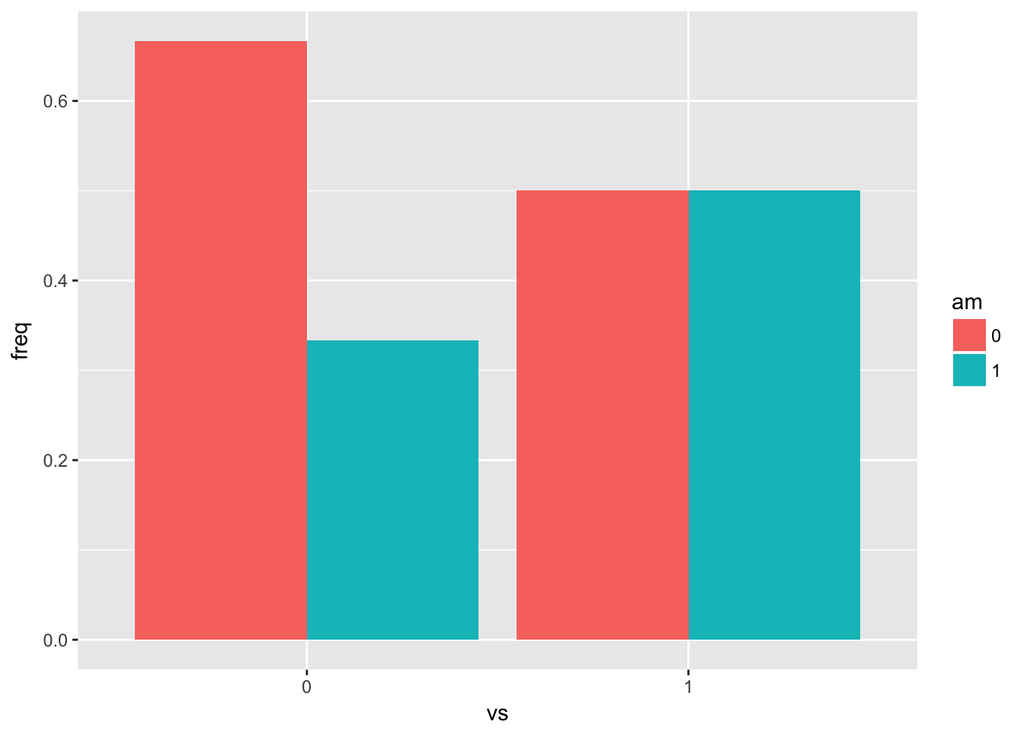

```r
# turn the crosstab into a proportion table and plot it
as.data.frame(prop.table(vs_am_xt, 1)) %>%
  select(., vs = vs_am.vs, am = vs_am.am, freq = Freq) %>%
  ggplot(., aes(x = vs, y = freq, fill = am)) +
  geom_col(position = 'dodge')
```